# Análisis de Datos con R - III. Manipulación

Sonia Mendizábal

04 de septiembre de 2016

> Las notas de este curso introductorio están basadas en el material de los profesores Ernesto Barrios, Andreu Boada, Luis Felipe González y Teresa Ortiz. Así como en el tutorial del Hadley Wickham y Garret Grolemund “R for Data Science”.

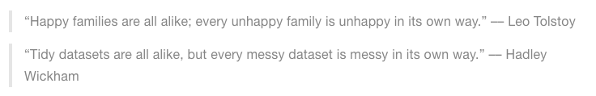

# 0. Introducción

En esta última sección del taller se concentrará el trabajo en la manipulación y tratamiento de los datos. El arte de tener tus datos en R listos para visualizar y modelar.

En el diagrama del proceso de análisis de datos (Hadley Wickham) de abajo se marcan las tareas que se desarrollarán:

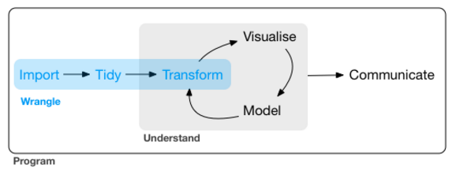

**Importante:** El tema de importación de datos se tocó en la primera sección, por lo que no se retomará.

#### Temas:

1. Datos limpios y reestructura de datos.
2. Estrategia **split-apply-combine**

#### Packages

Los paquetes que se usaran en esta sección son:

- `tidyr`: manipulación de datos
- `dplyr`: filtros, cálculos y agregación de datos.

Recuerda que primero es necesario instalar los paquetes con la función `install.packages()’ y el nombre del paquete debe ir entre comillas.

```r
install.packages('tidyr')
install.packages('dplyr')
```

Una vez instalados en R, se cargan ambas librerías en conjunto con las librerías usadas en las secciones anteriores.

```r
library(tidyr)
library(dplyr)
library(ggplot2)
library(stringr)
library(lubridate)
library(readr)
theme_set(theme_bw())
```

**Recuerda:** Las librerías se cargan en cada sesión nueva de R que abras. Las librerías se installan para cada versión de R nueva.

#### Pipeline

La idea de *pipeline* intenta hacer el desarrollo de código más fácil, en menor tiempo, fácil de leerlo, y por lo tanto, más fácil mantenerlo.

En el análisis de datos es común hacer varias operaciones y se vuelve difícil leer y entender el código. La dificultad radica en que usualmente los parámetros se asignan después del nombre de la función usando `()`.

La forma en que esta idea logra hacer las cosas más faciles es con el operador **forwad pipe** `%>%`que envía un valor a una expresión o función. Este cambio en el orden funciona como el parámetro que precede a la función es enviado (“piped”) a la función. Es decir, supongamos `x` es una valor y sea `f` una función, entonces, **`x %>% f` es igual a `f(x)`.**

Por ejemplo, sea f(x) la función de probabilidad de la distribución Normal con media $\mu = 0$ y desviación estándar $\sigma = 1$:
$$f(x) = \frac{ 1 }{\sqrt(2\pi)} e^{ (- \frac{1}{2} x^2 )}$$

```r
f <- function(x){
  exp(-(x^2)/2)/sqrt(2*pi)
}
# Con operador pipe
4 %>% f
```

```
## [1] 0.0001338302
```

que de forma tradicional se realiza:

```r
# Forma tradicional
f(4)
```

```
## [1] 0.0001338302
```

En resúmen `%>%` funciona:

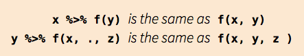

**Nota:** El shortcut del pipe `%>%` es command/ctrl + shift + m

> `Ejercicio`:
> 1. ¿Qué hace el siguiente código? ¿Qué hace `.`?

```r
df <- data_frame(
  x = runif(5),
  y = rnorm(5)
)
df %>% .$x
df %>%
  ggplot(data = ., aes(x = x, y = y)) +
    geom_point()
```

> 2. Imprime usando pipe `%>%` los primeros 10 elementos de `mpg`.

#### Tibbles

Tibbles son dataframes con algunas modificaciones que permitirán trabajar mejor con los paquetes de limpieza y manipulación de datos `tidyr` y `dplyr`.

Una diferencia son los tipos de columnas que maneja:

- `lgl:` verctore de valores logicos, vectores que contienen TRUE o FALSE.
- `int`: vectores de números enteros.
- `dbl`: vectores de número reales.
- `chr`: vectores de caracteres, *strings*.

> `Ejercicio`:
> 1. Imprime `ds` y `as.data.frame(ds)` ¿Cuál es la diferencias entre ambas?

```r
ds <- tbl_df(mtcars)
ds
as.data.frame(ds)
```

**Nota:** Para más información de este tipo de dataframes consulta la libreria `tibble`.

# 1. Datos limpios

Los datos limpios son datos que facilitan las tareas del análisis de datos:

- **Manipulación**: Manipulación de variables como agregar, filtrar, reordenar, transformar.
- **Visualización**: Resúmenes de datos usando gráficas, análisis exploratorio, o presentación de resultados.
- **Modelación**: Ajustar modelos es sencillo si los datos están en la forma correcta.

### Principios:

Los principios de datos limpios ([Tidy Data de Hadley Wickham]http://vita.had.co.nz/papers/tidy-data.pdf) proveen una manera estándar de organizar la información:

1. Cada variable forma una columna.
2. Cada observación forma un renglón.
3. Cada tipo de unidad observacional forma una tabla.

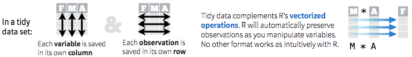

**Nota:** La mayor parte de las bases de datos en estadística tienen forma rectangular por lo que únicamente se trataran este tipo de estructura de datos.

Una **base de datos** es una colección de valores numéricos o categóricos. Cada valor pertenece a una variable y a una observación. Una **variable** contiene los valores del atributo (genero, fabricante, ingreso) de la variable por unidad. Una **observación** contiene todos los valores medidos por la misma unidad (personas, día, autos, municipios) para diferentes atributos.

### Ejemplo:

Supongamos un experimento con 3 pacientes cada uno tiene resultados de dos tratamientos (A y B):

|  | tratamientoA | tratamientoB |
| --- | --- | --- |
| Juan Aguirre | - | 2 |
| Ana Bernal | 16 | 11 |
| José López | 3 | 1 |

La tabla anterior también se puede estructurar de la siguiente manera:

|  | Juan Aguirre | Ana Bernal | José López |
| --- | --- | --- | --- |
| tratamientoA | - | 16 | 3 |
| tratamientoB | 2 | 11 | 1 |

Si vemos los principios ¿las tablas anteriores los cumplen? Para responder la pregunta veamos:

- **¿Cuáles son los valores?** En total se tienen 18 valores en el conjunto de datos.
- **¿Cuáles son las variables?** Se tienen tres variables:
1. Persona/nombre: Juan Aguirre, Ana Bernal, y José López
2. Tratamiento: A y B
3. Resultado: -, 2, 16, 11, 3, 1
- **¿Cuáles las observaciones?** Existen 6 observaciones.

Entonces, siguiendo los principios de *datos limpios* obtenemos la siguiente estructura:

| nombre | tratamiento | resultado |
| --- | --- | --- |
| Juan Aguirre | a | - |
| Ana Bernal | a | 16 |
| José López | a | 3 |
| Juan Aguirre | b | 2 |
| Ana Bernal | b | 11 |
| José López | b | 1 |

Una vez que identificamos los problemas de una base de datos podemos proceder a la limpieza.

### Funciones principales:

Para la limpieza de datos usaremos la librería `tidyr` como ya se mencionó y 4 funciones principales del paquete:

- `gather()`: junta columnas en renglones. También se le conoce como *melt*, derretir la base. Recibe múltiples columnas y las junta en pares de nombres y valores, convierte los datos anchos en largos.

`tidyr::gather(data, key = name_variablelabel, value = name_valuelabel, select_columns)`

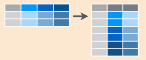

- `spread()`: separa renglones en columnas. Recibe dos columnas y las separa, haciendo los datos más anchos.

`tidyr::spread(data, key = name_variablelabel, value = name_valuelabel)`

- `unite()`: une varias columnas en una sola.

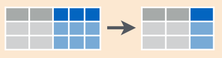

- `separate()`: separa una columna en varias columnas.

`tidyr::separate(data, col = name_variabletoseparate, into = c(vector with names using ""), sep)`

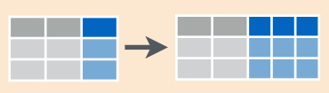

Otras funciones útiles:

- `arrange()`: ordena un dataframe de acuerdo a variables específicas.
- `rename()`: permite ronambrar variables.
- `select()`: selecciona variables.

Estas funciones se ejemplificaran en algunos de los problemas más comunes que se encuentran en conjuntos de datos sucios y se mostrará como se puede manipular la tabla de datos con el fin de estructurarla para que cumpla los principios de datos limpios.

### Problemas comúnes:

Algunos de los problemas más comunes en las bases de datos que no están *limpias* son:

1. Los encabezados de las columnas son valores y no nombres de variables.
2. Más de una variable por columna.
3. Las variables están organizadas tanto en filas como en columnas.
4. Más de un tipo de observación en una tabla.
5. Una misma unidad observacional está almacenada en múltiples tablas.

#### a. Encabezados de columnas son valores

Usaremos ejemplos para entender los conceptos más facilmente. La primer base de datos está basada en una encuesta de [Pew Research](http://www.pewforum.org/2009/01/30/income-distribution-within-us-religious-groups/) que investiga la relación entre ingreso y afiliación religiosa. ¿Cuáles son las variables en estos datos?

```r
# leemos la base
pew <- read.delim(file = "http://stat405.had.co.nz/data/pew.txt",
  header = TRUE, stringsAsFactors = FALSE, check.names = F)
pew %>% str()
```

```
## 'data.frame':    18 obs. of  11 variables:
##  $ religion          : chr  "Agnostic" "Atheist" "Buddhist" "Catholic" ...
##  $ <$10k             : int  27 12 27 418 15 575 1 228 20 19 ...
##  $ $10-20k           : int  34 27 21 617 14 869 9 244 27 19 ...
##  $ $20-30k           : int  60 37 30 732 15 1064 7 236 24 25 ...
##  $ $30-40k           : int  81 52 34 670 11 982 9 238 24 25 ...
##  $ $40-50k           : int  76 35 33 638 10 881 11 197 21 30 ...
##  $ $50-75k           : int  137 70 58 1116 35 1486 34 223 30 95 ...
##  $ $75-100k          : int  122 73 62 949 21 949 47 131 15 69 ...
##  $ $100-150k         : int  109 59 39 792 17 723 48 81 11 87 ...
##  $ >150k             : int  84 74 53 633 18 414 54 78 6 151 ...
##  $ Don't know/refused: int  96 76 54 1489 116 1529 37 339 37 162 ...
```

Para *limpiarla* es necesario apilar las columnas, es decir, alargar los datos. Esto lo realizaremos con la función `gather()` y los siguientes argumentos `tidyr::gather(data, key = name_variablelabel, value = name_valuelabel, select_columns)`:

```r
pew.long <- pew %>%
  gather(income, frequency, -religion)
# vemos las primeras líneas de nuestros datos alargados
head(pew.long)
```

```
##             religion income frequency
## 1           Agnostic  <$10k        27
## 2            Atheist  <$10k        12
## 3           Buddhist  <$10k        27
## 4           Catholic  <$10k       418
## 5 Don’t know/refused  <$10k        15
## 6   Evangelical Prot  <$10k       575
```

La nueva estructura de la base de datos nos permite, por ejemplo, hacer fácilmente una gráfica donde podemos comparar las diferencias en las frecuencias.

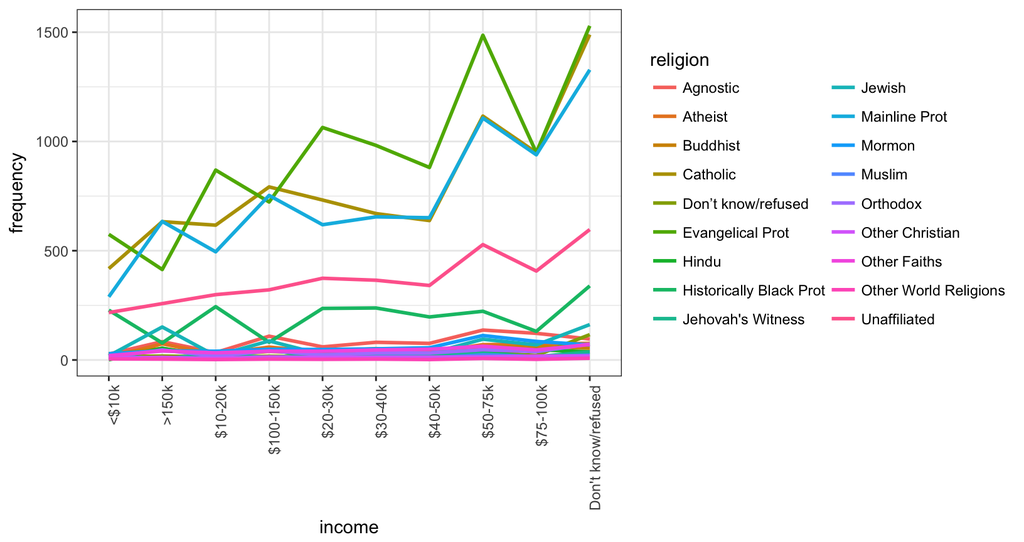

```r
ggplot(pew.long, aes(x = income, y = frequency,
                     color = religion, group = religion)) +
  geom_line(size = 1) +
  theme(axis.text.x = element_text(angle = 90, hjust = 1)) +
  guides(color = guide_legend(ncol=2))
```

#### b. Más de una variable por columna

La siguiente base de datos proviene de la Organización Mundial de la Salud y contiene el número de casos confirmados de tuberculosis por país y año, la información esta por grupo demográfico de acuerdo a sexo (m, f), y edad (0-4, 5-14, etc).

```r
tb <- read.csv("data/tb.csv") %>% tbl_df()
print(tb, n = 10, width = NULL)
```

```
## # A tibble: 5,769 × 22
##      iso2  year new_sp_m04 new_sp_m514 new_sp_m014 new_sp_m1524
## *  <fctr> <int>      <int>       <int>       <int>        <int>
## 1      AD  1989         NA          NA          NA           NA
## 2      AD  1990         NA          NA          NA           NA
## 3      AD  1991         NA          NA          NA           NA
## 4      AD  1992         NA          NA          NA           NA
## 5      AD  1993         NA          NA          NA           NA
## 6      AD  1994         NA          NA          NA           NA
## 7      AD  1996         NA          NA           0            0
## 8      AD  1997         NA          NA           0            0
## 9      AD  1998         NA          NA           0            0
## 10     AD  1999         NA          NA           0            0
## # ... with 5,759 more rows, and 16 more variables: new_sp_m2534 <int>,
## #   new_sp_m3544 <int>, new_sp_m4554 <int>, new_sp_m5564 <int>,
## #   new_sp_m65 <int>, new_sp_mu <int>, new_sp_f04 <int>,
## #   new_sp_f514 <int>, new_sp_f014 <int>, new_sp_f1524 <int>,
## #   new_sp_f2534 <int>, new_sp_f3544 <int>, new_sp_f4554 <int>,
## #   new_sp_f5564 <int>, new_sp_f65 <int>, new_sp_fu <int>
```

De manera similar al inciso a., utilizando la función `gather()` se busca apilar las columnas correspondientes a sexo-edad. **¿Cómo podemos separar la “variable” sexo-edad en dos columnas?**

```r
tb.long <- tb %>%
  gather(demog, casos, new_sp_m04:new_sp_fu, na.rm=TRUE)
  # gather(demog, casos, c(-iso2, -year), na.rm=TRUE) # otra forma
print(tb.long, n= 6)
```

```
## # A tibble: 35,750 × 4
##     iso2  year      demog casos
## * <fctr> <int>      <chr> <int>
## 1     AD  2005 new_sp_m04     0
## 2     AD  2006 new_sp_m04     0
## 3     AD  2008 new_sp_m04     0
## 4     AE  2006 new_sp_m04     0
## 5     AE  2007 new_sp_m04     0
## 6     AE  2008 new_sp_m04     0
## # ... with 3.574e+04 more rows
```

Las variables sexo y edad se obtienen separando la columna **demog**, para esto se usa la función `separate()`con los siguientes argumentos: `tidyr::separate(data, col = name_variabletoseparate, into = c(vector with names using ""), sep)`

```r
tb.tidy <- tb.long %>%
  separate(col = demog, into = c("sex", "age"), sep = 8)
tb.tidy
```

```
## # A tibble: 35,750 × 5
##      iso2  year      sex   age casos
## *  <fctr> <int>    <chr> <chr> <int>
## 1      AD  2005 new_sp_m    04     0
## 2      AD  2006 new_sp_m    04     0
## 3      AD  2008 new_sp_m    04     0
## 4      AE  2006 new_sp_m    04     0
## 5      AE  2007 new_sp_m    04     0
## 6      AE  2008 new_sp_m    04     0
## 7      AG  2007 new_sp_m    04     0
## 8      AL  2005 new_sp_m    04     0
## 9      AL  2006 new_sp_m    04     1
## 10     AL  2007 new_sp_m    04     0
## # ... with 35,740 more rows
```

Ahora para hacer mejor variable **sex** y **age** usaremos la función `mutate()` que permite crear nuevas variables sin modificar la dimensión del dataframe.

```r
tb.tidy <- tb.long %>%
  separate(col = demog, into = c("sex", "age"), sep = 8) %>%
  mutate( sex = str_sub(sex, 8, 8),
          age = factor(age,
                       levels = c("014", "04", "1524", "2534", "3544",
                                  "4554", "514",  "5564", "65","u"),
                       labels = c("0-14", "0-4", "15-24", "25-34", "35-44",
                                  "45-54", "5-14",  "55-64", "65+","unknown")
                       )
          )
print(tb.tidy, n = 6)
```

```
## # A tibble: 35,750 × 5
##     iso2  year   sex    age casos
##   <fctr> <int> <chr> <fctr> <int>
## 1     AD  2005     m    0-4     0
## 2     AD  2006     m    0-4     0
## 3     AD  2008     m    0-4     0
## 4     AE  2006     m    0-4     0
## 5     AE  2007     m    0-4     0
## 6     AE  2008     m    0-4     0
## # ... with 3.574e+04 more rows
```

#### c. Variables almacenadas en filas y columnas

Uno de los problemas más difícil es cuando las variables están tanto en filas como en columnas. Para este problema veamos una base de datos de Global Historical Climatology Network que contiente el clima por día en Cuernavaca (estación MX17004). ¿Cuáles son las variables en estos datos?

```r
clima <- read.delim("data/clima.txt", stringsAsFactors=FALSE) %>% tbl_df()
print(clima, n = 4)
```

```
## # A tibble: 22 × 35
##            id  year month element    d1    d2    d3    d4    d5    d6
##         <chr> <int> <int>   <chr> <int> <int> <int> <int> <int> <int>
## 1 MX000017004  2010     1    TMAX    NA    NA    NA    NA    NA    NA
## 2 MX000017004  2010     1    TMIN    NA    NA    NA    NA    NA    NA
## 3 MX000017004  2010     2    TMAX    NA   273   241    NA    NA    NA
## 4 MX000017004  2010     2    TMIN    NA   144   144    NA    NA    NA
## # ... with 18 more rows, and 25 more variables: d7 <int>, d8 <int>,
## #   d9 <lgl>, d10 <int>, d11 <int>, d12 <lgl>, d13 <int>, d14 <int>,
## #   d15 <int>, d16 <int>, d17 <int>, d18 <lgl>, d19 <lgl>, d20 <lgl>,
## #   d21 <lgl>, d22 <lgl>, d23 <int>, d24 <lgl>, d25 <int>, d26 <int>,
## #   d27 <int>, d28 <int>, d29 <int>, d30 <int>, d31 <int>
```

Estos datos tienen variables en columnas individuales (id, año, mes), en múltiples columnas (día, d1-d31) y en filas (tmin, tmax). Comencemos por apilar las columnas.

```r
clima.long <- clima %>%
  gather(day, value, d1:d31, na.rm = TRUE)
head(clima.long)
```

```
## # A tibble: 6 × 6
##            id  year month element   day value
##         <chr> <int> <int>   <chr> <chr> <int>
## 1 MX000017004  2010    12    TMAX    d1   299
## 2 MX000017004  2010    12    TMIN    d1   138
## 3 MX000017004  2010     2    TMAX    d2   273
## 4 MX000017004  2010     2    TMIN    d2   144
## 5 MX000017004  2010    11    TMAX    d2   313
## 6 MX000017004  2010    11    TMIN    d2   163
```

Podemos crear algunas variables adicionales con las funciones `tidyr::extract_numeric()`, `tidyr::select()` y `dplyr::arrange()`.

```r
clima.vars <- clima.long %>%
  mutate(day = extract_numeric(day), value = value / 10)  %>%
  select(id, year, month, day, element, value) %>%
  arrange(id, year, month, day)
```

```
## extract_numeric() is deprecated: please use readr::parse_numeric() instead
```

```r
head(clima.vars)
```

```
## # A tibble: 6 × 6
##            id  year month   day element value
##         <chr> <int> <int> <dbl>   <chr> <dbl>
## 1 MX000017004  2010     1    30    TMAX  27.8
## 2 MX000017004  2010     1    30    TMIN  14.5
## 3 MX000017004  2010     2     2    TMAX  27.3
## 4 MX000017004  2010     2     2    TMIN  14.4
## 5 MX000017004  2010     2     3    TMAX  24.1
## 6 MX000017004  2010     2     3    TMIN  14.4
```

Finalmente, la columna **element** no es una variable, sino que almacena el nombre de dos variables, la operación que debemos aplicar la función `spread()` que es el inverso de apilar `gather()`, la función usa los siguientes argumentos: `tidyr::spread(data, key = name_variablelabel, value = name_valuelabel)`

```r
clima.tidy <- clima.vars %>%
  spread(element, value)
head(clima.tidy)
```

```
## # A tibble: 6 × 6
##            id  year month   day  TMAX  TMIN
##         <chr> <int> <int> <dbl> <dbl> <dbl>
## 1 MX000017004  2010     1    30  27.8  14.5
## 2 MX000017004  2010     2     2  27.3  14.4
## 3 MX000017004  2010     2     3  24.1  14.4
## 4 MX000017004  2010     2    11  29.7  13.4
## 5 MX000017004  2010     2    23  29.9  10.7
## 6 MX000017004  2010     3     5  32.1  14.2
```

Ahora es inmediato no solo hacer gráficas sino también ajustar un modelo.

```r
# ajustamos un modelo lineal donde la variable respuesta es temperatura
# máxima, y la variable explicativa es el mes
clima.lm <- lm(TMAX ~ factor(month), data = clima.tidy)
summary(clima.lm)
```

```
##
## Call:
## lm(formula = TMAX ~ factor(month), data = clima.tidy)
##
## Residuals:
##    Min     1Q Median     3Q    Max
##  -3.65  -0.92  -0.02   1.05   3.18
##
## Coefficients:
##                 Estimate Std. Error t value Pr(>|t|)
## (Intercept)      27.8000     1.8610  14.938 5.34e-13 ***
## factor(month)2   -0.0500     2.0807  -0.024  0.98104
## factor(month)3    4.7667     2.1489   2.218  0.03717 *
## factor(month)4    8.5000     2.6319   3.230  0.00385 **
## factor(month)5    5.4000     2.6319   2.052  0.05228 .
## factor(month)6    1.2500     2.2793   0.548  0.58892
## factor(month)7    1.4500     2.2793   0.636  0.53123
## factor(month)8    0.4714     1.9895   0.237  0.81488
## factor(month)10   1.1000     2.0386   0.540  0.59491
## factor(month)11   0.3200     2.0386   0.157  0.87670
## factor(month)12   1.0500     2.2793   0.461  0.64955
## ---
## Signif. codes:  0 '***' 0.001 '**' 0.01 '*' 0.05 '.' 0.1 ' ' 1
##
## Residual standard error: 1.861 on 22 degrees of freedom
## Multiple R-squared:  0.6182, Adjusted R-squared:  0.4447
## F-statistic: 3.563 on 10 and 22 DF,  p-value: 0.006196
```

#### d. Mas de un tipo de observación en una misma tabla

En ocasiones las bases de datos involucran valores en diferentes niveles, en diferentes tipos de unidad observacional. En la limpieza de datos, cada unidad observacional debe estar almacenada en su propia tabla (esto esta ligado a normalización de una base de datos), es importante para evitar inconsistencias en los datos.

```r
billboard <- read.csv('data/billboard.csv') %>% tbl_df()
head(billboard)
```

```
## # A tibble: 6 × 81
##    year       artist                   track   time date.entered   wk1
##   <int>       <fctr>                  <fctr> <fctr>       <fctr> <int>
## 1  2000        2 Pac Baby Don't Cry (Keep...   4:22   2000-02-26    87
## 2  2000      2Ge+her The Hardest Part Of ...   3:15   2000-09-02    91
## 3  2000 3 Doors Down              Kryptonite   3:53   2000-04-08    81
## 4  2000 3 Doors Down                   Loser   4:24   2000-10-21    76
## 5  2000     504 Boyz           Wobble Wobble   3:35   2000-04-15    57
## 6  2000         98^0 Give Me Just One Nig...   3:24   2000-08-19    51
## # ... with 75 more variables: wk2 <int>, wk3 <int>, wk4 <int>, wk5 <int>,
## #   wk6 <int>, wk7 <int>, wk8 <int>, wk9 <int>, wk10 <int>, wk11 <int>,
## #   wk12 <int>, wk13 <int>, wk14 <int>, wk15 <int>, wk16 <int>,
## #   wk17 <int>, wk18 <int>, wk19 <int>, wk20 <int>, wk21 <int>,
## #   wk22 <int>, wk23 <int>, wk24 <int>, wk25 <int>, wk26 <int>,
## #   wk27 <int>, wk28 <int>, wk29 <int>, wk30 <int>, wk31 <int>,
## #   wk32 <int>, wk33 <int>, wk34 <int>, wk35 <int>, wk36 <int>,
## #   wk37 <int>, wk38 <int>, wk39 <int>, wk40 <int>, wk41 <int>,
## #   wk42 <int>, wk43 <int>, wk44 <int>, wk45 <int>, wk46 <int>,
## #   wk47 <int>, wk48 <int>, wk49 <int>, wk50 <int>, wk51 <int>,
## #   wk52 <int>, wk53 <int>, wk54 <int>, wk55 <int>, wk56 <int>,
## #   wk57 <int>, wk58 <int>, wk59 <int>, wk60 <int>, wk61 <int>,
## #   wk62 <int>, wk63 <int>, wk64 <int>, wk65 <int>, wk66 <lgl>,
## #   wk67 <lgl>, wk68 <lgl>, wk69 <lgl>, wk70 <lgl>, wk71 <lgl>,
## #   wk72 <lgl>, wk73 <lgl>, wk74 <lgl>, wk75 <lgl>, wk76 <lgl>
```

La instrucción `na.rm = TRUE` se utiliza para eliminar los valores faltantes en las columnas **wk1** a **wk76**. Realizamos una limpieza adicional creando mejores variables de fecha y duración.

```r
billboard.tidy <- billboard %>%
  gather(week, rank, wk1:wk76, na.rm=TRUE) %>%
  mutate(
    week = extract_numeric(week), # tidyr: número de semana
    date = as.Date(date.entered) + (7 * (week - 1)) # lubriate: operaciones de fechas
    ) %>%
  select(-date.entered)
```

```
## extract_numeric() is deprecated: please use readr::parse_numeric() instead
```

Separemos esta base de datos en las dos variables que tenemos: duración de la canción **time** y ranking de la canción en cada semana **rank**.

La primera tabla **song** almacena artista, nombre de la canción y duración. Además se agrega una variable **song_id**.

```r
library(forcats)
song <- billboard.tidy %>%
  select(artist, track, year, time) %>%
  unique() %>%
  mutate(song_id = row_number(artist),
         time.ms = ms(time),
         # lubridate: duracion en minutos y segundos
         time.secs = as.numeric(minute(time.ms))*60 +
           as.numeric(seconds(time.ms)),
         # forcats: recodificación de artistas top 5 con mas canciones en el rank
         artist.top = fct_lump(artist,n = 1)

    ) %>%
  select(-time.ms)
dim(song)
```

```
## [1] 317   7
```

```r
song
```

```
## # A tibble: 317 × 7
##            artist                   track  year   time song_id time.secs
##            <fctr>                  <fctr> <int> <fctr>   <int>     <dbl>
## 1           2 Pac Baby Don't Cry (Keep...  2000   4:22       1       502
## 2         2Ge+her The Hardest Part Of ...  2000   3:15       2       375
## 3    3 Doors Down              Kryptonite  2000   3:53       3       413
## 4    3 Doors Down                   Loser  2000   4:24       4       504
## 5        504 Boyz           Wobble Wobble  2000   3:35       5       395
## 6            98^0 Give Me Just One Nig...  2000   3:24       6       384
## 7         A*Teens           Dancing Queen  2000   3:44       7       404
## 8         Aaliyah           I Don't Wanna  2000   4:15       8       495
## 9         Aaliyah               Try Again  2000   4:03       9       483
## 10 Adams, Yolanda           Open My Heart  2000   5:30      10       630
## # ... with 307 more rows, and 1 more variables: artist.top <fctr>
```

La segunda tabla **rank** almacena el ranking de la canción en cada semana por **song_id**.

```r
rank <- billboard.tidy %>%
  left_join(song, by = c("artist", "track", "year", "time")) %>%
  select(song_id, artist, date, rank) %>%
  arrange(song_id, date)
dim(rank)
```

```
## [1] 5307    4
```

```r
rank
```

```
## # A tibble: 5,307 × 4
##    song_id  artist       date  rank
##      <int>  <fctr>     <date> <int>
## 1        1   2 Pac 2000-02-26    87
## 2        1   2 Pac 2000-03-04    82
## 3        1   2 Pac 2000-03-11    72
## 4        1   2 Pac 2000-03-18    77
## 5        1   2 Pac 2000-03-25    87
## 6        1   2 Pac 2000-04-01    94
## 7        1   2 Pac 2000-04-08    99
## 8        2 2Ge+her 2000-09-02    91
## 9        2 2Ge+her 2000-09-09    87
## 10       2 2Ge+her 2000-09-16    92
## # ... with 5,297 more rows
```

La función `left_join()` tiene los siguientes argumentos: `dplyr::left_join(x, y, by = c(vector de variables por las que unir ""))` que une dos tablas: `x` y `y`. Pega `y` a `x` de tal forma que regresa todos los renglones de `x` y todas las columnas de `x` y `y`.

Así es posible hacer gráficas facilmente para cada variable.

- Distribución de la duración de canciones del Top 100 en 2000:

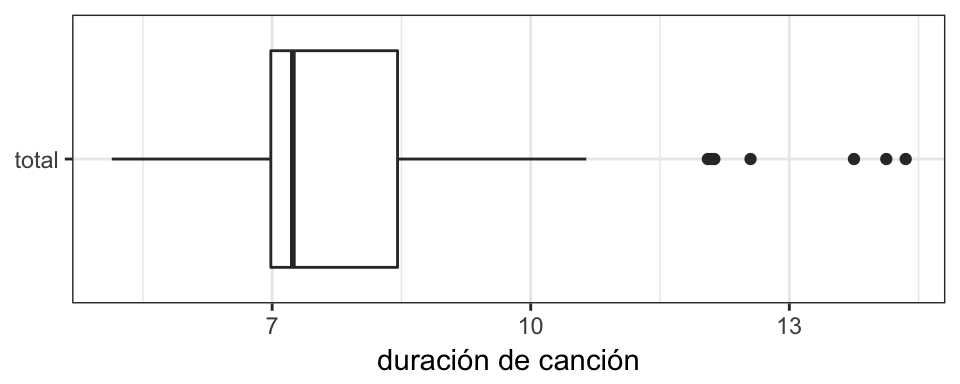

```r
ggplot(song, aes(x = 'total', y = time.secs)) +
  geom_boxplot() +
  scale_y_continuous(labels = function(x) round(x/60)) +
  ylab('duración de canción') +
  xlab(NULL) +
  coord_flip()
```

- Artista con más canciones en Top 100 de 2000:

```r
tracks <- rank %>%
  inner_join(song %>%  filter(artist.top != 'Other'))
```

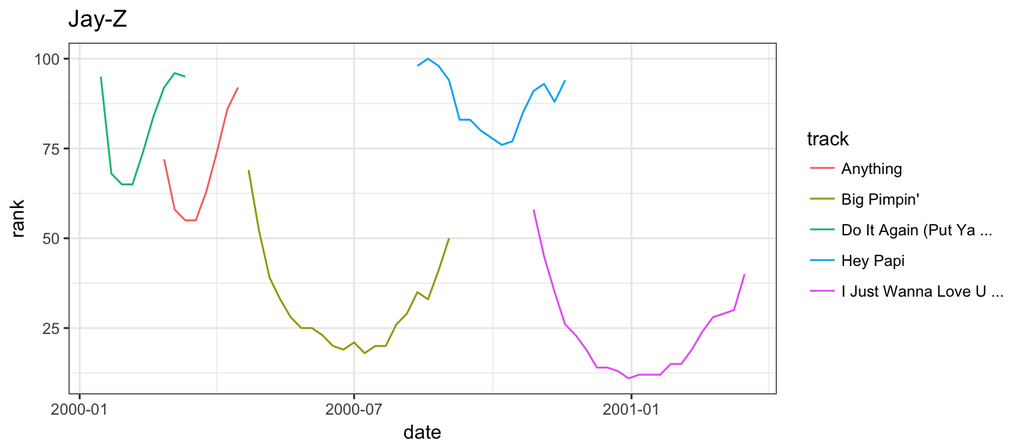

```r
ggplot(tracks, aes(x = date, y = rank,
                   group = track, color = track)) +
  geom_line() +
  ggtitle( unique(tracks$artist))
```

- Boy bands de mi adolescencia en 2000:

```r
tracks.boyband <- rank %>%
  inner_join( filter(song,
                     artist %in% c('Backstreet Boys, The', "N'Sync") )
              )
```

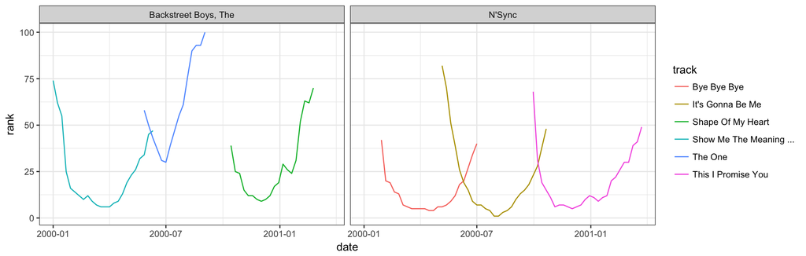

```r
ggplot(tracks.boyband, aes(x = date, y = rank,
                   group = track, color = track)) +
  geom_line() +
  facet_wrap(~artist)
```

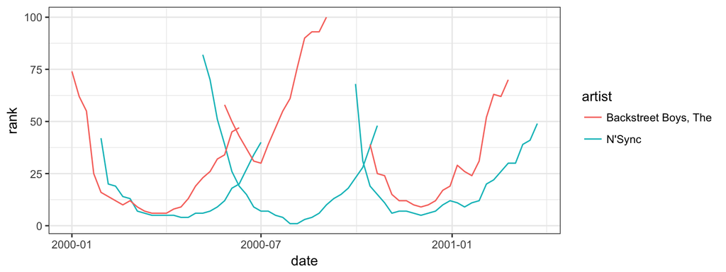

```r
ggplot(tracks.boyband, aes(x = date, y = rank,
                   group = track, color = artist)) +
  geom_line()
```

#### e. Una misma unidad observacional almacenada en varias tablas

También es común que los valores sobre una misma unidad observacional estén separados en muchas tablas o archivos (INEGI), es común que estas tablas esten divididas de acuerdo a una variable, de tal manera que cada archivo representa a una persona, año o ubicación. Para juntar los archivos hacemos lo siguiente:

1. Leemos los archivos en una lista de tablas.
2. Para cada tabla agregamos una columna que registra el nombre del archivo original.
3. Combinamos las tablas en un solo data frame.

Veamos un ejemplo, la carpeta **specdata** contiene 332 archivos csv que almacenan información de monitoreo de contaminación en 332 ubicaciones de EUA. Cada archivo contiene información de una unidad de monitoreo y el número de identificación del monitor es el nombre del archivo.

- Creamos un vector con los nombres de los archivos en un directorio, eligiendo aquellos que contengan las letras *“.csv”*.

```r
paths <- dir("data/specdata", pattern = "\\.csv$", full.names = TRUE)
```

- Creamos una función para leer los archivos .csv y se itera por cada path con la función `lapply()`. Esto devuelve una lista y unimos las tablas con la función `rbind_all()` de `dplyr`. Finalmente, se crean nuevas variables.

```r
ReadCsvPath <- function(path){
  tab <- read.csv(file = path, stringsAsFactors = FALSE)
  tab$monitor <- extract_numeric(path)
  tab
}
specdata <- lapply(paths, ReadCsvPath) %>%
  rbind_all() %>%
  tbl_df() %>%
  mutate(
    date = as.Date(Date)) %>%
  select(id = ID, monitor, date, sulfate, nitrate)
head(specdata)
```

#### f. Otras consideraciones

En las buenas prácticas es importante tomar en cuenta los siguientes puntos:

- Incluir un encabezado con el nombre de las variables.
- Los nombres de las variables deben ser entendibles (e.g. AgeAtDiagnosis es mejor que AgeDx).
- En general los datos se deben guardar en un archivo por tabla.
- Escribir un script con las modificaciones que se hicieron a los *datos crudos* (reproducibilidad).
- Otros aspectos importantes en la *limpieza* de datos son: selección del tipo de variables (por ejemplo fechas), datos faltantes, *typos* y detección de valores atípicos.

> `Ejercicio:`

> I. Obten los datos del problema común **e. specdata** y obten **una** gráfica de la serie por tipo de medida: **nitrate** y **sulfate** para un monitor cualquiera. Coloreando cada serie por tipo de medida. Agrega la siguiente función `scale_y_log10()` a la gráfica anterior ¿qué sucede?
> 2. Importa la tabla de frecuencias **tabej1.csv** de adopciones por tipo animal de un refugio. Realiza una tabla de forma ancha para la frecuencia **n** y otra para la proporción **prop**. Renombra la columna categórica: **outcomtype frecuencia** o **outcomtype proporción** a las columnas dependiendo de la tabla.
> 3. Para este ejercicio vamos a usar datos sobre edad en años de perros y gatos adpotados del refugio de Austin Animal Center. Los datos fueron tomados de ASPCA. La base se llama **adoptions2.csv**.

> Esta tabla tiene información de varias variables en una variable y valores en variables: a. Obten la forma larga de la base. b. Separa **sexuponoutcome** para obtener una variable del sexo del animal. (Tip: usa la función `separate()`)
> 4. Para seguir practicando:
> - Usando la base **billboard.csv** evalúa el efecto Britney Spears vs. Christina Aguilera.
> - Descarga la base de mortalidad en México e intenta graficar el número de muertes por hora en el año 2008. ¿Qué observas?

```r
src <- "https://github.com/hadley/mexico-mortality/raw/master/deaths/deaths08.csv.bz2"
download.file(url = src, "data/deaths.csv.bz2", quiet = TRUE)
```

# 2. Split - Apply - Combine

Muchos problemas de análisis de datos involucran la aplicación de la estrategia **divide-aplica-combina** ([Hadley Whickam, 2011](http://www.jstatsoft.org/v40/i01/paper)). Esta consiste en romper un problema en pedazos (de acuerdo a una variable de interés), operar sobre cada subconjunto de manera independiente (ej. calcular la media de cada grupo, ordenar observaciones por  
grupo, estandarizar por grupo) y después unir los pedazos nuevamente.

1. **Separa** la base de datos original.
2. **Aplica** funciones a cada subconjunto.
3. **Combina** los resultados en una nueva base de datos.

Cuando pensamos como implementar la estrategia divide-aplica-combina es natural pensar en iteraciones, por ejemplo utilizar un ciclo `for` para recorrer cada grupo de interés y aplicar las funciones. Sin embargo, la aplicación de ciclos `for` desemboca en código difícil de entender. Adicionalmente, `dplyr` es mucho más veloz.

Estudiaremos las siguientes funciones:

- **filter**: obten un subconjunto de las filas de acuerdo a un criterio.
- **select**: selecciona columnas de acuerdo al nombre.
- **arrange**: reordena las filas.
- **mutate**: agrega nuevas variables.
- **summarise**: reduce variables a valores (crear nuevas bases de datos).

Estas funciones trabajan de manera similar, el primer argumento que reciben es un *data frame* (usualmente en formato *limpio*), los argumentos que siguen indican que operación se va a efectuar y el resultado es un nuevo *data frame*.

Veamos con ejemplos con la siguiente ase de datos sencilla para mostrar el funcionamiento de cada instrucción.

```r
df_ej <- data.frame(genero = c("mujer", "hombre", "mujer", "mujer", "hombre"),
                    estatura = c(1.65, 1.80, 1.70, 1.60, 1.67))
df_ej
```

```
##   genero estatura
## 1  mujer     1.65
## 2 hombre     1.80
## 3  mujer     1.70
## 4  mujer     1.60
## 5 hombre     1.67
```

#### - Filtrar

Filtrar una base de datos dependiendo de una condición requiere la función `filter()` que tiene los siguientes argumentos `dplyr::filter(data, condition)`.

```r
filter(df_ej, genero == "mujer")
```

```
##   genero estatura
## 1  mujer     1.65
## 2  mujer     1.70
## 3  mujer     1.60
```

```r
filter(df_ej, estatura > 1.65 & estatura < 1.75)
```

```
##   genero estatura
## 1  mujer     1.70
## 2 hombre     1.67
```

Algunos operadores importantes para filtrar son:

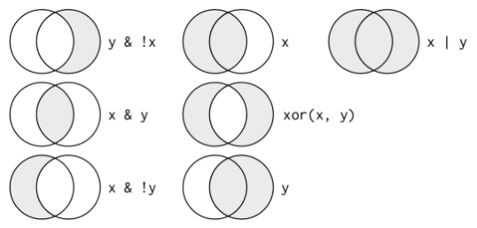

```r
x > 1
x >= 1
x < 1
x <= 1
x != 1
x == 1
x %in% ("a", "b")

# Conjuntos
a | b
a & b
a & !b
xor(a, b)
```

#### - Seleccionar

Elegir columnas de un conjunto de datos se puede hacer con la función `select()` que tiene los siguientes argumentos `dplyr::select(data, seq_variables)`.

```r
df_ej
```

```
##   genero estatura
## 1  mujer     1.65
## 2 hombre     1.80
## 3  mujer     1.70
## 4  mujer     1.60
## 5 hombre     1.67
```

```r
select(df_ej, genero)
```

```
##   genero
## 1  mujer
## 2 hombre
## 3  mujer
## 4  mujer
## 5 hombre
```

```r
select(df_ej, -genero)
```

```
##   estatura
## 1     1.65
## 2     1.80
## 3     1.70
## 4     1.60
## 5     1.67
```

También, existen funciones que se usan exclusivamente en `select()`:

- `starts_with(x, ignore.case = TRUE)`: los nombres empiezan con *x*.
- `ends_with(x, ignore.case = TRUE)`: los nombres terminan con *x*.
- `contains(x, ignore.case = TRUE)`: selecciona las variable que contengan *x*.
- `matches(x, ignore.case = TRUE)`: selecciona las variable que igualen la expresión regular *x*.
- `num_range("x", 1:5, width = 2)`: selecciona las variables (numericamente) de x01 a x05.
- `one_of("x", "y", "z")`: selecciona las variables que esten en un vector de caracteres.
- `everything()`: selecciona todas las variables.

Por ejemplo:

```r
select(df_ej, starts_with("g"))
select(df_ej, contains("g"))
```

#### - Arreglar

Arreglar u ordenar de acuerdo al valor de una o más variables es posible con la función `arrange()` que tiene los siguientes argumentos `dplyr::arrange(data, variables_por_las_que_ordenar)`. La función `desc()` permite que se ordene de forma descendiente.

```r
arrange(df_ej, genero)
```

```
##   genero estatura
## 1 hombre     1.80
## 2 hombre     1.67
## 3  mujer     1.65
## 4  mujer     1.70
## 5  mujer     1.60
```

```r
arrange(df_ej, desc(estatura))
```

```
##   genero estatura
## 1 hombre     1.80
## 2  mujer     1.70
## 3 hombre     1.67
## 4  mujer     1.65
## 5  mujer     1.60
```

#### - Mutar

Mutar consiste en crear nuevas variables con la función `mutate()` que tiene los siguientes argumentos `dplyr::mutate(data, nuevas_variables = operaciones)`:

```r
mutate(df_ej, estatura_cm = estatura * 100)
```

```
##   genero estatura estatura_cm
## 1  mujer     1.65         165
## 2 hombre     1.80         180
## 3  mujer     1.70         170
## 4  mujer     1.60         160
## 5 hombre     1.67         167
```

```r
mutate(df_ej,
       estatura_cm = estatura * 100,
       estatura_in = estatura_cm * 0.3937)
```

```
##   genero estatura estatura_cm estatura_in
## 1  mujer     1.65         165     64.9605
## 2 hombre     1.80         180     70.8660
## 3  mujer     1.70         170     66.9290
## 4  mujer     1.60         160     62.9920
## 5 hombre     1.67         167     65.7479
```

#### - Resúmenes por Grupo

Los resúmenes permiten crear nuevas bases de datos que son agregaciones de los datos originales. La función `summarise()` permite realizar este resúmen `dplyr::summarise(data, nuevas_variables = operaciones)`:

```r
dplyr::summarise(df_ej, promedio = mean(estatura))
```

```
##   promedio
## 1    1.684
```

También es posible hacer resúmenes agrupando por variables determinadas de la base de datos. Pero, primero es necesario crear una base agrupada con la función `group_by()` con argumentos `dplyr::group_by(data, add = variables_por_agrupar)`:

```r
by_genero <- group_by(df_ej, genero)
by_genero
```

```
## Source: local data frame [5 x 2]
## Groups: genero [2]
##
##   genero estatura
##   <fctr>    <dbl>
## 1  mujer     1.65
## 2 hombre     1.80
## 3  mujer     1.70
## 4  mujer     1.60
## 5 hombre     1.67
```

Después se opera sobre cada grupo, creando un resumen a nivel grupo y uniendo los subconjuntos en una base nueva:

```r
dplyr::summarise(by_genero, promedio = mean(estatura))
```

```
## # A tibble: 2 × 2
##   genero promedio
##   <fctr>    <dbl>
## 1 hombre    1.735
## 2  mujer    1.650
```

Algunas funciones útiles con *summarise* son min(x), median(x), max(x), quantile(x, p), n(), sum(x), sum(x > 1), mean(x > 1), sd(x).

Una de las funciones más útiles es la función `do()`. Esta función permite realizar calculos que regresan otro dataframe u objetos en una lista. Es muy útil cuando se trabaja con modelos, a continuación se da un ejemplo:

```r
models <- mpg %>%
  group_by(manufacturer) %>%
  do(mod = lm(hwy ~ displ, data = .))
models
```

```
## Source: local data frame [15 x 2]
## Groups: <by row>
##
## # A tibble: 15 × 2
##    manufacturer      mod
## *         <chr>   <list>
## 1          audi <S3: lm>
## 2     chevrolet <S3: lm>
## 3         dodge <S3: lm>
## 4          ford <S3: lm>
## 5         honda <S3: lm>
## 6       hyundai <S3: lm>
## 7          jeep <S3: lm>
## 8    land rover <S3: lm>
## 9       lincoln <S3: lm>
## 10      mercury <S3: lm>
## 11       nissan <S3: lm>
## 12      pontiac <S3: lm>
## 13       subaru <S3: lm>
## 14       toyota <S3: lm>
## 15   volkswagen <S3: lm>
```

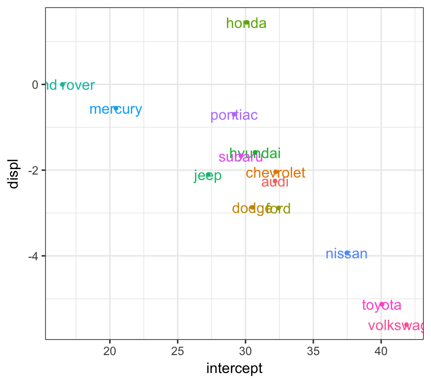

```r
tab.coefs <- lapply(models$mod, function(mod){ data.frame(t(coef(mod))) }) %>%
  rbind_all() %>%
  rename(intercept = `X.Intercept.`) %>%
  mutate(manufacturer = models$manufacturer)

ggplot(tab.coefs, aes(x = intercept, y = displ,
                      color = manufacturer)) +
  geom_text(aes(label = manufacturer),
            check_overlap = F,
             show.legend = F) +
  geom_point(show.legend = F, size = 1)
```

> `Ejercicio:`

> I. De los datos obtenidos de adopciones que ya trabajaste en el ejercicio anterior para tenerla en forma *limpia*, ahora podemos analizar:
> 1. Obten el día de la semana y el mes en el que el animal fue adoptado.
> 2. Realiza una gráfica de dispersión con suavizamiento de días de la semana por número de salidas coloreando por tipo de salida. (Tip: Obten una tabla de frecuencias por **weekday** y **outcometype** usando las funciones `group_by()` y `tally()`)
> 3. Una vez que tienes la tabla de frecuencias intenta adaptar el código para que puedas obtener la gráfica de calor. ¿Qué observas?
> 4. Únicamente para los animales adoptados:
> - Histograma de la edad de adopción
> - Histograma de la edad de adopción por género
> - Boxplot de la edad de adopción por tipo de animal

```r
ggplot(tab.freq,
       aes(x = outcometype, y = wdays,
           fill = n)) +
  geom_tile(colour = "white") +
  scale_fill_gradient(low = "white", high = "steelblue") +
  ylab(NULL) + xlab(NULL) +
  ggtitle('Tipos de Egresos')
```

# 3. CASO NYC FLIGHTS

> Para el siguiente ejercicio se usará el paquete `nycflights13`. Este paquete incluye los datos de los vuelos que salieron de NYC (EWR, JFK and LGA) en 2013. Además tiene información complementaria de el clima, aerolíneas, aviones y aeropuertos.

> El paquete se compone de 5 tablas:
> - `flight`: información de los vuelos.
> - `weather`: datos meteorológicos por hora por aeropuerto.
> - `planes`: información de construcción de cada avión.
> - `airports`: localización y nombre de aeropuertos.
> - `airlines`: codigos de nombre de aerolínea.

> Total de vuelos: 336,776.

```r
library(nycflights13)
```

> El siguiente diagrama muestra variables con las que se conectan las diferentes tablas.

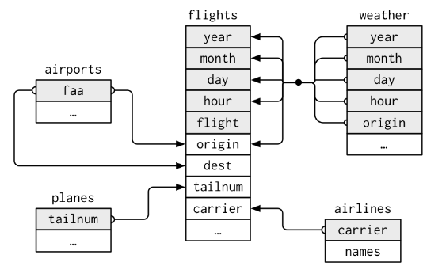

> Se desea saber:
> - Todos los vuelos hacia SFO ó OAK.
> - ¿Cuáles son los diez vuelos con mayor retraso de salida? ¿Cuál es el nombre de las aerolíneas son y a qué destino se dirigen?
> - Se quiere saber si existe relación de distacia y retraso promedio por cada destino. Considera quitar ‘datos ruidosos’, ¿qué vuelos consideras atípicos? ¿Crees que se deban de quitar destinos con pocos vuelos del análisis?
> - ¿Qué destinos tienen mayor número de aerolíneas con la ruta? ¿Cuál es el nombre completo de las aerolíneas que vuelan en la ruta con más aerolíneas?
> - ¿Existe relación entre el tiempo promedio de retraso y el mes del año? ¿Se observa relación con el número de vuelos por mes? ¿Cómo lo presentarías en una sola gráfia? -Observa el número de vuelos cancelados por día. ¿Existe un patrón? ¿Está relacionada la proporción de vuelos con al retraso promedio del día?
> - ¿A qué hora es recomendable volar si quieres evitar retrasos en la hora de salida?

**Recomendación:** Si normalmente trabajas con datos grandes (por ejemplo 10-100 Gb), se recomienda la libreria `data.table`. En este caso únicamente trataremos datos ligeros, pero todas las funciones que trataremos para la manipulación son aplicables a datos de `data.table`.

# 4. Referencias

- **Tidy Data**. *Hadley Wickham*. Journal of Statistical Software. August 2014, Volume 59, Issue 10. https://www.jstatsoft.org/article/view/v059i10
- R for Data Analysis. Septiembre 2016. http://r4ds.had.co.nz/wrangle-intro.html
- Data Wrangling with **tidyr** and **dplyr** - Cheat Sheet. Septiembre 2016. https://www.rstudio.com/wp-content/uploads/2015/02/data-wrangling-cheatsheet.pdf
- Cheatsheet for **dplyr* Join Functions. Septiembre 2016. http://stat545.com/bit001_dplyr-cheatsheet.html
- NYC Flights 2013. Septiembre 2016. https://github.com/hadley/nycflights13
- Mortality data for Mexico. Septiembre 2016.  
  https://github.com/hadley/mexico-mortality/raw/master/deaths/deaths08.csv.bz2
- Kaggle Shelter Animal Outcomes. Septiembre 2016.  
  https://www.kaggle.com/c/shelter-animal-outcomes